# Compare Size Effect of Spatial Units(SESU)

**gdverse** provides the `sesu_opgd()` and `sesu_gozh()` function to support the selection of optimal spatial analysis scales which based on **OPGD** and **GOZH** respectively. Please refer to the help documentation of the corresponding function for more details.

Here, we use [FVC raster data](https://github.com/SpatLyu/rdevdata/blob/main/FVC.tif) as an example to demonstrate the optimal spatial analysis scale selection function in **gdverse**.

## Processing data

First, we construct FVC data under different spatial units using the original data.

```r
library(terra)
library(tidyverse)
library(gdverse)
fvcpath = "https://github.com/SpatLyu/rdevdata/raw/main/FVC.tif"
fvc = terra::rast(paste0("/vsicurl/",fvcpath))
fvc
## class       : SpatRaster
## dimensions  : 418, 568, 13  (nrow, ncol, nlyr)
## resolution  : 1000, 1000  (x, y)
## extent      : -92742.16, 475257.8, 3591385, 4009385  (xmin, xmax, ymin, ymax)
## coord. ref. : Asia_North_Albers_Equal_Area_Conic
## source      : FVC.tif
## names       :       fvc,   premax,   premin,   presum,    tmpmax,     tmpmin, ...
## min values  : 0.1363270, 109.8619,  2.00000, 3783.904,  9.289694, -11.971293, ...
## max values  : 0.9596695, 249.9284, 82.74928, 8549.112, 26.781870,   1.322163, ...
```

The original data resolution is `1000`m, and then we construct the data under `2000-10000` m spatial units with 1000 spatial unit interval.

```r
su = seq(1000,10000,by = 1000)
fvc1000 = tibble::as_tibble(terra::as.data.frame(fvc,na.rm = T))
fvc_other = 2:10 %>%
  purrr::map(\(.x) terra::aggregate(fvc,fact=.x ,fun="mean") %>%
               terra::as.data.frame(na.rm = T) %>%
               tibble::as_tibble())
fvc = c(list(fvc1000),fvc_other)
str(fvc)
```

```
## List of 10
##  $ : tibble [136,243 × 13] (S3: tbl_df/tbl/data.frame)
##   ..$ fvc   : num [1:136243] 0.198 0.193 0.192 0.189 0.208 ...
##   ..$ premax: num [1:136243] 163 161 160 159 164 ...
##   ..$ premin: num [1:136243] 7.95 6.8 5.24 5 9.98 ...
##   ..$ presum: num [1:136243] 3956 3892 3842 3808 4051 ...
##   ..$ tmpmax: num [1:136243] 20.8 20.7 20.9 21.1 20.6 ...
##   ..$ tmpmin: num [1:136243] -7.53 -7.55 -7.48 -7.39 -7.59 ...
##   ..$ tmpavg: num [1:136243] 8.05 8.02 8.15 8.35 7.97 ...
##   ..$ pop   : num [1:136243] 1.903 1.203 0.547 0.542 10.392 ...
##   ..$ ntl   : num [1:136243] 6.6 4.91 3.75 3.99 7.1 ...
##   ..$ lulc  : num [1:136243] 10 10 10 10 10 10 10 10 10 10 ...
##   ..$ elev  : num [1:136243] 1758 1754 1722 1672 1780 ...
##   ..$ slope : num [1:136243] 2.65 3.45 3.96 2.9 1.94 ...
##   ..$ aspect: num [1:136243] 176.4 169.6 138.5 110.9 99.5 ...
##  $ : tibble [33,722 × 13] (S3: tbl_df/tbl/data.frame)
##   ..$ fvc   : num [1:33722] 0.195 0.184 0.157 0.204 0.208 ...
##   ..$ premax: num [1:33722] 162 159 167 165 165 ...
##   ..$ premin: num [1:33722] 7.37 5.14 4.21 10.98 9.8 ...
##   ..$ presum: num [1:33722] 3935 3799 3975 4134 4089 ...
##   ..$ tmpmax: num [1:33722] 20.9 21.3 21.1 20.4 20.9 ...
##   ..$ tmpmin: num [1:33722] -7.39 -7.21 -7.3 -7.62 -7.33 ...
##   ..$ tmpavg: num [1:33722] 8.17 8.5 8.49 7.78 8.2 ...
##   ..$ pop   : num [1:33722] 18.69 0.91 8.94 10.31 6.46 ...
##   ..$ ntl   : num [1:33722] 6.15 4.32 2.14 4.64 6.79 ...
##   ..$ lulc  : num [1:33722] 10 10 10 10 10 10 10 10 10 10 ...
##   ..$ elev  : num [1:33722] 1720 1638 1662 1835 1717 ...
##   ..$ slope : num [1:33722] 3.89 2.63 3.06 3.37 3.93 ...
##   ..$ aspect: num [1:33722] 114 158 136 102 120 ...
##  $ : tibble [14,840 × 13] (S3: tbl_df/tbl/data.frame)
##   ..$ fvc   : num [1:14840] 0.205 0.197 0.175 0.163 0.21 ...
##   ..$ premax: num [1:14840] 165 161 160 162 165 ...
##   ..$ premin: num [1:14840] 10.35 6.02 4.97 4.48 11.04 ...
##   ..$ presum: num [1:14840] 4098 3908 3848 3910 4131 ...
##   ..$ tmpmax: num [1:14840] 20.7 21.2 21.5 21.3 20.4 ...
##   ..$ tmpmin: num [1:14840] -7.46 -7.19 -7.07 -7.24 -7.52 ...
##   ..$ tmpavg: num [1:14840] 8.04 8.44 8.67 8.52 7.84 ...
##   ..$ pop   : num [1:14840] 12.33 13.78 4.59 6.52 2.97 ...
##   ..$ ntl   : num [1:14840] 6.37 7.79 7.23 9.96 4.59 ...
##   ..$ lulc  : num [1:14840] 10 10 10 10 10 10 10 10 10 10 ...
```

[output cut: 86 more lines]

```
##   ..$ aspect: num [1:1561] 137 191 175 177 150 ...
##  $ : tibble [1,253 × 13] (S3: tbl_df/tbl/data.frame)
##   ..$ fvc   : num [1:1253] 0.177 0.177 0.178 0.186 0.19 ...
##   ..$ premax: num [1:1253] 164 164 169 160 162 ...
##   ..$ premin: num [1:1253] 5.22 3.56 3.34 10.52 7.39 ...
##   ..$ presum: num [1:1253] 4046 3990 4098 4058 4069 ...
##   ..$ tmpmax: num [1:1253] 21.5 21.6 21.5 21.2 21 ...
##   ..$ tmpmin: num [1:1253] -6.98 -6.96 -7.07 -6.86 -6.98 ...
##   ..$ tmpavg: num [1:1253] 8.77 8.86 8.79 8.68 8.4 ...
##   ..$ pop   : num [1:1253] 6.1 18.38 8.83 9.96 8.91 ...
##   ..$ ntl   : num [1:1253] 7.901 11.324 9.294 0.611 2.963 ...
##   ..$ lulc  : num [1:1253] 10 10 10 10 10 10 10 10 10 10 ...
##   ..$ elev  : num [1:1253] 1581 1547 1552 1640 1692 ...
##   ..$ slope : num [1:1253] 2.41 2.83 3.04 2.29 2.85 ...
##   ..$ aspect: num [1:1253] 130 182 211 194 163 ...
```

## Comparison of Size Effect of Spatial Units based on OPGD model

```r
discvar = names(select(fvc1000,-c(fvc,lulc)))
g1 = sesu_opgd(fvc ~ ., data = fvc,su = su,discvar = discvar,cores = 12)
g1
```

```
##    Size Effect Of Spatial Units Using OPGD Model
##  ***    Optimal Spatial Unit: 8000
##  Spatial Unit: 1000
##
## | variable | Q-statistic | P-value  |
## |:--------:|:-----------:|:--------:|
## |  presum  | 0.629224208 | 3.28e-10 |
## |   lulc   | 0.553328610 | 9.11e-10 |
## |  premin  | 0.418432585 | 9.07e-10 |
## |  tmpmin  | 0.388351007 | 2.38e-10 |
## |  tmpmax  | 0.202221646 | 3.41e-10 |
## |   elev   | 0.201323643 | 4.71e-10 |
## |  slope   | 0.191360672 | 4.72e-10 |
## |  tmpavg  | 0.180958844 | 9.66e-10 |
## |   pop    | 0.162710129 | 1.22e-10 |
## |  premax  | 0.123992358 | 2.18e-10 |
## |   ntl    | 0.015565222 | 5.63e-10 |
## |  aspect  | 0.006274855 | 3.51e-10 |
##
##  Spatial Unit: 2000
##
## | variable | Q-statistic | P-value  |
## |:--------:|:-----------:|:--------:|
## |  presum  | 0.63312876  | 3.11e-10 |
## |   lulc   | 0.52874942  | 8.96e-10 |
## |  premin  | 0.42455258  | 9.24e-10 |
## |  tmpmin  | 0.39556928  | 4.95e-10 |
## |  tmpmax  | 0.21303636  | 8.76e-10 |
## |   elev   | 0.20843509  | 6.73e-10 |
## |  slope   | 0.20649212  | 7.76e-10 |
## |  tmpavg  | 0.19219842  | 6.67e-10 |
## |   pop    | 0.16400743  | 1.32e-10 |
## |  premax  | 0.12681440  | 5.15e-10 |
## |   ntl    | 0.01517344  | 4.57e-10 |
## |  aspect  | 0.00842302  | 3.92e-10 |
##
##  Spatial Unit: 3000
##
## | variable | Q-statistic | P-value  |
## |:--------:|:-----------:|:--------:|
```

[output cut: 116 more lines]

```
##
## | variable | Q-statistic |   P-value    |
## |:--------:|:-----------:|:------------:|
## |  presum  | 0.66343981  | 4.000000e-10 |
## |   lulc   | 0.49588376  | 7.880000e-10 |
## |  premin  | 0.46911366  | 2.190000e-10 |
## |  tmpmin  | 0.44824499  | 2.090000e-10 |
## |   elev   | 0.25805475  | 8.600000e-11 |
## |  tmpmax  | 0.25711048  | 2.570000e-10 |
## |  tmpavg  | 0.23844293  | 2.680000e-10 |
## |  slope   | 0.22356559  | 9.870000e-10 |
## |   pop    | 0.21293610  | 9.630000e-10 |
## |  premax  | 0.13851805  | 1.160000e-10 |
## |  aspect  | 0.04068517  | 6.566287e-01 |
## |   ntl    | 0.02368926  | 9.871909e-01 |
```

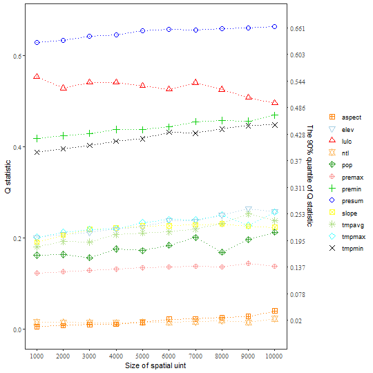

```r
plot(g1)
```

## Comparison of Size Effect of Spatial Units based on GOZH model

```r
g2 = sesu_gozh(fvc ~ ., data = fvc, su = su,
               cores = 12, increase_rate = 0.005)
g2
```

```
##    Size Effect Of Spatial Units Using GOZH Model
##  ***        Optimal Spatial Unit: 4000
##  Spatial Unit: 1000
##
## |   variable    | Q-statistic | P-value  |
## |:-------------:|:-----------:|:--------:|
## | TotalVariable |  0.7866938  | 3.33e-10 |
##
##  Spatial Unit: 2000
##
## |   variable    | Q-statistic | P-value  |
## |:-------------:|:-----------:|:--------:|
## | TotalVariable |  0.7975525  | 4.96e-10 |
##
##  Spatial Unit: 3000
##
## |   variable    | Q-statistic | P-value  |
## |:-------------:|:-----------:|:--------:|
## | TotalVariable |  0.8038107  | 9.51e-10 |
##
##  Spatial Unit: 4000
##
## |   variable    | Q-statistic | P-value  |
## |:-------------:|:-----------:|:--------:|
## | TotalVariable |  0.8120727  | 7.54e-10 |
##
##  Spatial Unit: 5000
##
## |   variable    | Q-statistic | P-value  |
## |:-------------:|:-----------:|:--------:|
## | TotalVariable |  0.8051771  | 7.15e-10 |
##
##  Spatial Unit: 6000
##
## |   variable    | Q-statistic | P-value  |
## |:-------------:|:-----------:|:--------:|
## | TotalVariable |  0.8285607  | 6.23e-10 |
##
##  Spatial Unit: 7000
##
## |   variable    | Q-statistic | P-value  |
## |:-------------:|:-----------:|:--------:|
## | TotalVariable |  0.8356357  | 7.91e-10 |
##
##  Spatial Unit: 8000
##
## |   variable    | Q-statistic | P-value  |
## |:-------------:|:-----------:|:--------:|
## | TotalVariable |  0.8194033  | 3.28e-10 |
##
##  Spatial Unit: 9000
##
## |   variable    | Q-statistic | P-value  |
## |:-------------:|:-----------:|:--------:|
## | TotalVariable |  0.8494805  | 3.79e-10 |
##
##  Spatial Unit: 10000
##
## |   variable    | Q-statistic | P-value  |
## |:-------------:|:-----------:|:--------:|
## | TotalVariable |  0.8182764  | 3.27e-10 |
```

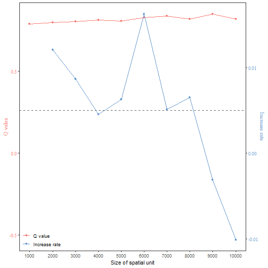

```r
plot(g2)
```

You can also use the same strategy as `sesu_opgd()` (use the mean of the individual Q statistic for all explanatory variables) in `sesu_gozh()` by assign `strategy` to `1`.

```r
g3 = sesu_gozh(fvc ~ ., data = fvc, su = su, cores = 12,
               strategy = 1, increase_rate = 0.005)
g3
```

```
##    Size Effect Of Spatial Units Using GOZH Model
##  ***        Optimal Spatial Unit: 10000
##  Spatial Unit: 1000
##
## | variable | Q-statistic | P-value  |
## |:--------:|:-----------:|:--------:|
## |  presum  | 0.61357308  | 2.33e-10 |
## |   lulc   | 0.54039924  | 7.28e-10 |
## |  premin  | 0.43005723  | 2.63e-10 |
## |  tmpmin  | 0.37878995  | 8.57e-10 |
## |   elev   | 0.19589469  | 8.32e-10 |
## |  tmpavg  | 0.19354399  | 6.54e-10 |
## |  tmpmax  | 0.18257181  | 4.90e-10 |
## |   pop    | 0.18188771  | 6.91e-10 |
## |  slope   | 0.18039771  | 3.92e-10 |
## |  premax  | 0.11278088  | 1.60e-10 |
## |   ntl    | 0.01298068  | 1.34e-10 |
## |  aspect  | 0.00000000  |   NaN    |
##
##  Spatial Unit: 2000
##
## | variable | Q-statistic | P-value  |
## |:--------:|:-----------:|:--------:|
## |  presum  | 0.62301279  | 2.66e-10 |
## |   lulc   | 0.55803717  | 8.77e-10 |
## |  premin  | 0.43544867  | 7.00e-10 |
## |  tmpmin  | 0.38618203  | 2.45e-10 |
## |  tmpmax  | 0.21025124  | 2.07e-10 |
## |   elev   | 0.20314330  | 2.78e-10 |
## |  tmpavg  | 0.19914975  | 7.39e-10 |
## |  slope   | 0.19627348  | 7.61e-10 |
## |   pop    | 0.19602997  | 4.70e-10 |
## |  premax  | 0.12512115  | 8.76e-10 |
## |   ntl    | 0.01303962  | 1.61e-10 |
## |  aspect  | 0.00000000  |   NaN    |
##
##  Spatial Unit: 3000
##
## | variable | Q-statistic | P-value  |
## |:--------:|:-----------:|:--------:|
```

[output cut: 116 more lines]

```
##
## | variable | Q-statistic |   P-value    |
## |:--------:|:-----------:|:------------:|
## |  presum  | 0.67041293  | 8.870000e-10 |
## |   lulc   | 0.62850681  | 3.530000e-10 |
## |  premin  | 0.48291514  | 5.270000e-10 |
## |  tmpmin  | 0.44485438  | 4.530000e-10 |
## |  tmpmax  | 0.28867471  | 4.140000e-10 |
## |  tmpavg  | 0.28656169  | 5.160000e-10 |
## |   elev   | 0.27080523  | 8.150000e-10 |
## |   pop    | 0.26912522  | 8.240000e-10 |
## |  slope   | 0.22656703  | 8.810000e-10 |
## |  premax  | 0.14956177  | 1.950000e-10 |
## |  aspect  | 0.03267780  | 2.524895e-03 |
## |   ntl    | 0.02332034  | 1.395206e-02 |
```

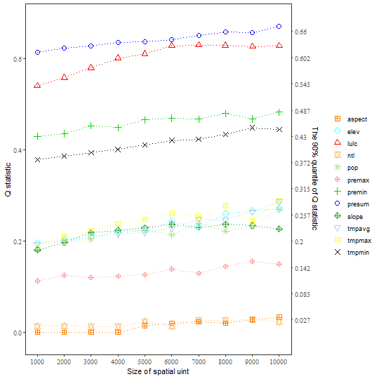

```r
plot(g3)
```

As shown above, strategy `2` results in a better trade-off between spatial unit expressive detail and explanatory power than strategy `1`. So `sesu_gozh()` defaults to use strategy `2`(using the interactive Q statistic for all explanatory variables)